# ANLY 530 - Assignment 1: Decision Tree Analysis

October 02, 2026

```r
library(rpart)
library(rpart.plot)
df <- read.csv("breast_cancer_dataset.csv")
```

# Part 1: Data Understanding and Preparation

## Inspection

```r
dim(df)
```

```
## [1] 569  10
```

```r
str(df)
```

```
## 'data.frame':    569 obs. of  10 variables:
##  $ clump_thickness            : int  5 5 3 6 4 8 1 2 2 4 ...
##  $ uniformity_of_cell_size    : int  1 4 1 8 1 10 1 1 1 2 ...
##  $ uniformity_of_cell_shape   : int  1 4 1 8 1 10 1 2 1 1 ...
##  $ marginal_adhesion          : int  1 5 1 1 3 8 1 1 1 1 ...
##  $ single_epithelial_cell_size: int  2 7 2 3 2 7 2 2 2 2 ...
##  $ bare_nuclei                : int  1 10 2 4 1 10 10 1 1 1 ...
##  $ bland_chromatin            : int  3 3 3 3 3 9 3 3 1 2 ...
##  $ normal_nucleoli            : int  1 2 1 7 1 7 1 1 1 1 ...
##  $ mitosis                    : int  1 1 1 1 1 1 1 1 5 1 ...
##  $ class                      : int  2 2 2 2 2 4 2 2 2 2 ...
```

```r
summary(df)
```

```
##  clump_thickness uniformity_of_cell_size uniformity_of_cell_shape
##  Min.   : 1.00   Min.   : 1.000          Min.   : 1.000
##  1st Qu.: 2.00   1st Qu.: 1.000          1st Qu.: 1.000
##  Median : 4.00   Median : 1.000          Median : 2.000
##  Mean   : 4.54   Mean   : 3.185          Mean   : 3.265
##  3rd Qu.: 6.00   3rd Qu.: 5.000          3rd Qu.: 5.000
##  Max.   :10.00   Max.   :10.000          Max.   :10.000
##  marginal_adhesion single_epithelial_cell_size  bare_nuclei
##  Min.   : 1.000    Min.   : 1.000              Min.   :-100000
##  1st Qu.: 1.000    1st Qu.: 2.000              1st Qu.:      1
##  Median : 1.000    Median : 2.000              Median :      1
##  Mean   : 2.845    Mean   : 3.299              Mean   :  -2633
##  3rd Qu.: 4.000    3rd Qu.: 4.000              3rd Qu.:      8
##  Max.   :10.000    Max.   :10.000              Max.   :     10
##  bland_chromatin normal_nucleoli     mitosis           class
##  Min.   : 1.00   Min.   : 1.000   Min.   : 1.000   Min.   :2.000
##  1st Qu.: 2.00   1st Qu.: 1.000   1st Qu.: 1.000   1st Qu.:2.000
##  Median : 3.00   Median : 1.000   Median : 1.000   Median :2.000
##  Mean   : 3.49   Mean   : 2.989   Mean   : 1.638   Mean   :2.731
##  3rd Qu.: 5.00   3rd Qu.: 4.000   3rd Qu.: 1.000   3rd Qu.:4.000
##  Max.   :10.00   Max.   :10.000   Max.   :10.000   Max.   :4.000
```

The file has 569 rows, and each row is a fine needle aspirate from one breast mass. The response is `class`. I am using the coding from the UCI Breast Cancer Wisconsin (Original) documentation: **2 = benign, 4 = malignant**. The other nine columns are the predictors: clump thickness, uniformity of cell size, uniformity of cell shape, marginal adhesion, single epithelial cell size, bare nuclei, bland chromatin, normal nucleoli and mitosis. A cytologist scores each of them from 1 to 10, with higher scores meaning more abnormal cells, so they are ordinal rather than truly continuous. A tree split like “< 2.5” therefore just means “scored 1 or 2”. The data agree with this coding: the high scores belong to class 4.

## Class distribution

```r
table(df$class)
```

```
##
##   2   4
## 361 208
```

```r
round(prop.table(table(df$class)), 3)
```

```
##
##     2     4
## 0.634 0.366
```

The data is about 63% benign and 37% malignant, so benign is the majority class. This is not severe imbalance, but it matters. A model can reach roughly 63% accuracy without ever detecting a cancer, which means accuracy has to be compared against that floor. Malignant-class metrics such as sensitivity and precision also need to be reported alongside accuracy. And with only about 40 malignant cases in a 20% test set, one missed cancer moves sensitivity by about 2.5 points.

## Data quality

```r
predictors <- setdiff(names(df), "class")
data.frame(min = sapply(df[predictors], min),
           max = sapply(df[predictors], max),
           n_missing = sapply(df[predictors], function(x) sum(is.na(x))),
           n_outside_1_to_10 = sapply(df[predictors], function(x) sum(!x %in% 1:10)))
```

|  | min | max | n_missing | n_outside_1_to_10 |
| --- | --- | --- | --- | --- |
| clump_thickness | 1e+00 | 10 | 0 | 0 |
| uniformity_of_cell_size | 1e+00 | 10 | 0 | 0 |
| uniformity_of_cell_shape | 1e+00 | 10 | 0 | 0 |
| marginal_adhesion | 1e+00 | 10 | 0 | 0 |
| single_epithelial_cell_size | 1e+00 | 10 | 0 | 0 |
| bare_nuclei | -1e+05 | 10 | 0 | 15 |
| bland_chromatin | 1e+00 | 10 | 0 | 0 |
| normal_nucleoli | 1e+00 | 10 | 0 | 0 |
| mitosis | 1e+00 | 10 | 0 | 0 |

```r
bad <- df$bare_nuclei == -100000
table(class_of_bad_rows = df$class[bad])
```

```
## class_of_bad_rows
##  2  4
## 13  2
```

```r
sum(duplicated(df))
```

```
## [1] 172
```

Eight of the predictors are clean. `bare_nuclei` contains 15 rows with the value **-100000**, which cannot occur on a 1 to 10 scale and is clearly a code for a missing value. R reads it as an ordinary number, so nothing flags it. A tree would treat it as an extremely low bare-nuclei score, which is the benign-looking end of the scale. That would quietly bias the variable the model relies on most, and it pushes the mean of the column to about -2,600.

I recoded these values to `NA` and dropped the 15 rows, which is 2.6% of the data. I chose not to impute: setting them to the median (1) would make every one of these cases look like it has normal nuclei, and two of them are malignant. Dropping so few rows barely changes the class balance. The cost is that the final model has no tested rule for a case with missing bare nuclei.

There are also 172 exact duplicate rows. I kept them. With nine discrete scores, different patients can easily share the same profile (the all-ones benign profile is very common), there is no patient ID to show that a row is a repeat, and no duplicated profile has conflicting labels.

**Assumptions:**

- The class coding is 2 = benign, 4 = malignant. This is the assumption the results depend on most. If it were reversed, every interpretation would flip.
- -100000 means “missing” and those rows are missing at random. They are 13 benign and 2 malignant, so they lean benign compared with the full data. If missingness were related to the diagnosis, the results would not fully carry over to incomplete cases.
- Each row is a separate patient. If the duplicates are actually repeated records, identical rows can land in both the training and test sets and inflate test performance (checked below).
- Scores were assigned consistently. The tree uses hard cut-offs, so a lab that scores differently would push cases across them.

## Preparation

```r
df$bare_nuclei[df$bare_nuclei == -100000] <- NA
df <- na.omit(df)
df$class <- factor(df$class, levels = c(2, 4), labels = c("benign", "malignant"))
str(df)
```

```
## 'data.frame':    554 obs. of  10 variables:
##  $ clump_thickness            : int  5 5 3 6 4 8 1 2 2 4 ...
##  $ uniformity_of_cell_size    : int  1 4 1 8 1 10 1 1 1 2 ...
##  $ uniformity_of_cell_shape   : int  1 4 1 8 1 10 1 2 1 1 ...
##  $ marginal_adhesion          : int  1 5 1 1 3 8 1 1 1 1 ...
##  $ single_epithelial_cell_size: int  2 7 2 3 2 7 2 2 2 2 ...
##  $ bare_nuclei                : int  1 10 2 4 1 10 10 1 1 1 ...
##  $ bland_chromatin            : int  3 3 3 3 3 9 3 3 1 2 ...
##  $ normal_nucleoli            : int  1 2 1 7 1 7 1 1 1 1 ...
##  $ mitosis                    : int  1 1 1 1 1 1 1 1 5 1 ...
##  $ class                      : Factor w/ 2 levels "benign","malignant": 1 1 1 1 1 2 1 1 1 1 ...
##  - attr(*, "na.action")= 'omit' Named int [1:15] 24 41 140 146 159 165 236 250 276 293 ...
##   ..- attr(*, "names")= chr [1:15] "24" "41" "140" "146" ...
```

```r
table(df$class)
```

```
##
##    benign malignant
##       348       206
```

# Part 2: Evaluation Strategy

## Positive class

```r
positive_class <- "malignant"
```

I treat **malignant (code 4)** as the positive class, because cancer is the condition the model is meant to detect. With this choice, sensitivity is the share of cancers the model catches, specificity is the share of benign masses it correctly clears, and precision is how often a “malignant” prediction is correct. That is the natural way to read a diagnostic test.

## Majority-class baseline

```r
baseline_acc <- max(prop.table(table(df$class)))
round(baseline_acc, 3)
```

```
## [1] 0.628
```

Always predicting “benign” gives 62.8% accuracy, with 0% sensitivity and 100% specificity. A tree has to clearly beat this to be useful. The baseline also shows why accuracy can mislead: a classifier that catches no cancers at all still gets over 60%.

## Train/test split

```r
set.seed(1)
train_idx <- unlist(lapply(split(seq_len(nrow(df)), df$class),
                           function(i) sample(i, round(0.8 * length(i)))))
train_data <- df[train_idx, ]
test_data  <- df[-train_idx, ]

rbind(train = table(train_data$class), test = table(test_data$class))
```

```
##       benign malignant
## train    278       165
## test      70        41
```

```r
# test rows whose exact predictor profile also appears in training
key <- function(d) do.call(paste, d[predictors])
n_overlap <- sum(key(test_data) %in% key(train_data))
n_overlap
```

```
## [1] 49
```

I used a stratified split: 80% of the benign rows and 80% of the malignant rows were sampled separately, with a fixed seed so the split is reproducible. This gives 443 training rows and 111 test rows, and both sets are about 37% malignant. I stratified because a purely random split of only about 200 malignant cases could leave the training set short of cancers or give the test set a different class mix. Accuracy and precision depend on the class mix, so the scores would then partly reflect luck in the split rather than the model.

The test set has to stay untouched because its only job is to estimate performance on new patients. If it is used to fit the model or to pick settings, the model is partly tuned to those 111 cases and the reported score is biased upward. All tuning here uses the training data only.

One caveat: 49 of the 111 test rows (44%) have a predictor profile that also appears in training, mostly very common benign profiles. Test scores are likely somewhat optimistic for that reason.

# Part 3: Baseline Decision Tree

```r
model_baseline <- rpart(class ~ ., data = train_data, method = "class")
model_baseline
```

```
## n= 443
##
## node), split, n, loss, yval, (yprob)
##       * denotes terminal node
##
##  1) root 443 165 benign (0.62753950 0.37246050)
##    2) uniformity_of_cell_shape< 2.5 253   8 benign (0.96837945 0.03162055) *
##    3) uniformity_of_cell_shape>=2.5 190  33 malignant (0.17368421 0.82631579)
##      6) bare_nuclei< 2.5 36  13 benign (0.63888889 0.36111111)
##       12) single_epithelial_cell_size< 3.5 22   0 benign (1.00000000 0.00000000) *
##       13) single_epithelial_cell_size>=3.5 14   1 malignant (0.07142857 0.92857143) *
##      7) bare_nuclei>=2.5 154  10 malignant (0.06493506 0.93506494) *
```

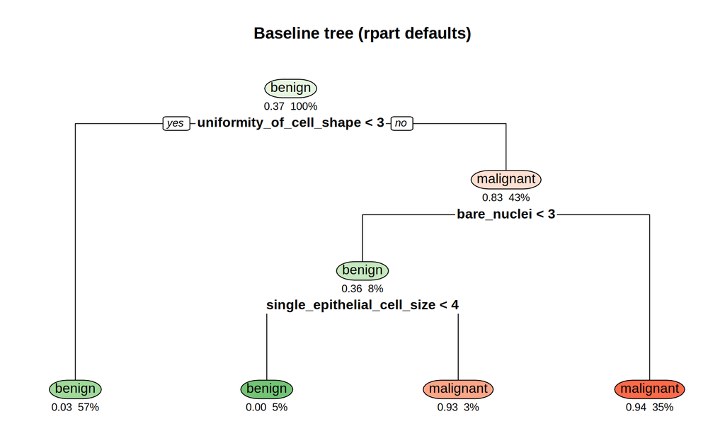

```r
rpart.plot(model_baseline, type = 2, extra = 106, under = TRUE, box.palette = "GnRd",
           main = "Baseline tree (rpart defaults)")
```

```r
round(model_baseline$variable.importance, 1)
```

```
##    uniformity_of_cell_shape     uniformity_of_cell_size
##                       147.6                       126.1
##                 bare_nuclei single_epithelial_cell_size
##                       113.0                       109.2
##             normal_nucleoli             bland_chromatin
##                       101.8                        85.6
##             clump_thickness           marginal_adhesion
##                        10.0                         8.4
```

**Root split.** The tree first splits on `uniformity_of_cell_shape` at 2.5, which separates scores of 1 or 2 from scores of 3 and above. Cases with uniform cell shape (253 of 443 training rows) are only 3% malignant and are predicted benign immediately. Cases with irregular shape are 83% malignant. This one split removes about 75% of the training error. In other words, whether the cells look alike is by far the strongest single signal. That fits the biology: benign tissue has regular cells, while cancer cells vary in shape.

**Second split.** Within the irregular-shape branch, the tree asks about `bare_nuclei`. A score of 3 or more leads to the largest malignant leaf, with 154 cases that are 94% malignant. A low bare-nuclei score leaves a small mixed group of 36 cases (about 36% malignant), which the tree resolves with `single_epithelial_cell_size`. Small cells (1 to 3) are predicted benign, and larger cells (4 or more) are predicted malignant.

**In plain terms,** the tree calls a mass malignant when the cells are irregular in shape **and** there are either many bare nuclei or enlarged epithelial cells. Otherwise it calls the mass benign. Every split sends the higher, more abnormal score toward malignant, which makes sense clinically. The importance scores show that `uniformity_of_cell_size` is almost as informative as cell shape even though it is not in the tree. The two are highly correlated (r = 0.9), so they largely carry the same information. Mitosis contributes almost nothing.

## Training performance

```r
evaluate <- function(model, data) {
  pred <- predict(model, data, type = "class")
  cm <- table(Actual = data$class, Predicted = pred)
  TP <- cm["malignant", "malignant"]; FN <- cm["malignant", "benign"]
  FP <- cm["benign", "malignant"];    TN <- cm["benign", "benign"]
  sens <- TP / (TP + FN); prec <- TP / (TP + FP)
  list(cm = cm,
       metrics = c(Accuracy = (TP + TN) / sum(cm), Sensitivity = sens,
                   Specificity = TN / (TN + FP), Precision = prec,
                   F1 = 2 * prec * sens / (prec + sens), FN = FN, FP = FP))
}
train_base <- evaluate(model_baseline, train_data)
train_base$cm
```

```
##            Predicted
## Actual      benign malignant
##   benign       267        11
##   malignant      8       157
```

```r
round(train_base$metrics, 3)
```

```
##    Accuracy Sensitivity Specificity   Precision          F1          FN
##       0.957       0.952       0.960       0.935       0.943       8.000
##          FP
##      11.000
```

On the training data the tree is 95.7% accurate, with 95.2% sensitivity and 96% specificity. I see no strong sign of overfitting. The tree has only 4 leaves, the smallest leaf still holds 14 cases, and the tree still makes 19 training errors, whereas an overfit tree would push training error toward zero. The weak spot is the 8 missed cancers. All of them sit in the “uniform shape, predict benign” leaf, so they are cancers that look bland on the strongest variable.

# Part 4: Model Complexity

I fit two additional trees that move complexity in opposite directions from the default:

```r
model_full <- rpart(class ~ ., data = train_data, method = "class",
                    control = rpart.control(cp = 0, minsplit = 2, minbucket = 1))

model_controlled <- rpart(class ~ ., data = train_data, method = "class",
                          control = rpart.control(maxdepth = 2, minbucket = 10))
model_controlled
```

```
## n= 443
##
## node), split, n, loss, yval, (yprob)
##       * denotes terminal node
##
## 1) root 443 165 benign (0.62753950 0.37246050)
##   2) uniformity_of_cell_shape< 2.5 253   8 benign (0.96837945 0.03162055) *
##   3) uniformity_of_cell_shape>=2.5 190  33 malignant (0.17368421 0.82631579)
##     6) bare_nuclei< 2.5 36  13 benign (0.63888889 0.36111111) *
##     7) bare_nuclei>=2.5 154  10 malignant (0.06493506 0.93506494) *
```

[output not shown]

**Why these settings.** `maxdepth = 2` limits every prediction to two questions. The baseline spends its third level on a split that covers only 36 training cases (about 8%), and I wanted to see whether that rule is worth keeping or is just fitting a small, noisy group. `minbucket = 10` makes sure each leaf’s probability is based on at least 10 patients. The fully grown tree (`cp = 0`, `minsplit = 2`, `minbucket = 1`) is not a candidate for use. It shows what happens when complexity is not controlled at all. I chose all of these settings before looking at the test results.

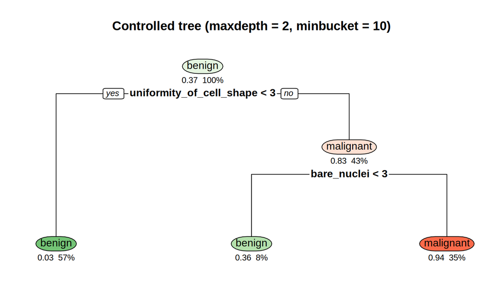

```r
rpart.plot(model_controlled, type = 2, extra = 106, under = TRUE, box.palette = "GnRd",
           main = "Controlled tree (maxdepth = 2, minbucket = 10)")
```

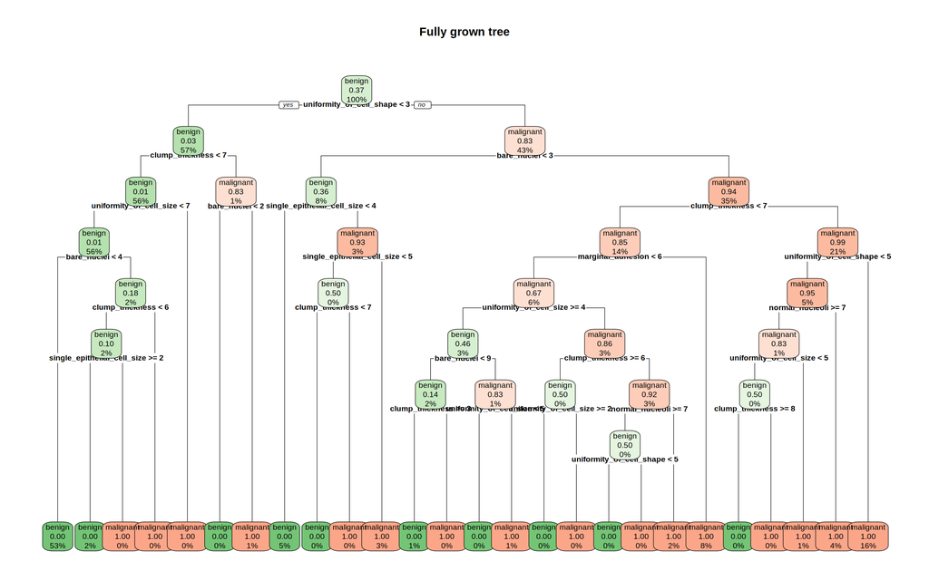

```r
rpart.plot(model_full, type = 2, extra = 106, cex = 0.6, box.palette = "GnRd",
           main = "Fully grown tree")
```

**How the structure changed.** The controlled tree keeps the same two top splits as the baseline (cell shape, then bare nuclei) and drops only the epithelial cell size split. The mixed group of 36 cases becomes a single benign leaf. The fully grown tree goes to 26 leaves and depth 8, and many of its leaves hold only 1 to 3 patients. Those lower splits isolate individual unusual cases rather than general patterns. All three trees share the same root, so the main signal is stable. They differ only in how far they chase the small, ambiguous groups.

**Training vs. test performance.**

```r
acc <- function(m, d) mean(predict(m, d, type = "class") == d$class)
models <- list(Full = model_full, Baseline = model_baseline, Controlled = model_controlled)
round(sapply(models, function(m) c(train = acc(m, train_data), test = acc(m, test_data))), 3)
```

```
##        Full Baseline Controlled
## train 1.000    0.957      0.930
## test  0.955    0.991      0.982
```

Making the tree more complex raised training accuracy but lowered test accuracy. The fully grown tree fits the training data perfectly (100%) but drops to 95.5% on the test set. The baseline and controlled trees have lower training accuracy (95.7% and 93%) but higher test accuracy (99.1% and 98.2%). The baseline and controlled trees are the ones likely to generalize. Neither shows a gap between training and test performance, their leaves are large, and their splits follow the strongest variables. The fully grown tree’s large drop from training to test is direct evidence that it memorized noise.

# Part 5: Model Evaluation (Test Set)

Malignant is the positive class in all of the results below.

## Baseline tree

```r
test_base <- evaluate(model_baseline, test_data)
test_base$cm
```

```
##            Predicted
## Actual      benign malignant
##   benign        70         0
##   malignant      1        40
```

```r
round(test_base$metrics, 3)
```

```
##    Accuracy Sensitivity Specificity   Precision          F1          FN
##       0.991       0.976       1.000       1.000       0.988       1.000
##          FP
##       0.000
```

## Controlled tree

```r
test_ctrl <- evaluate(model_controlled, test_data)
test_ctrl$cm
```

```
##            Predicted
## Actual      benign malignant
##   benign        70         0
##   malignant      2        39
```

```r
round(test_ctrl$metrics, 3)
```

```
##    Accuracy Sensitivity Specificity   Precision          F1          FN
##       0.982       0.951       1.000       1.000       0.975       2.000
##          FP
##       0.000
```

## Fully grown tree

```r
test_full <- evaluate(model_full, test_data)
test_full$cm
```

```
##            Predicted
## Actual      benign malignant
##   benign        70         0
##   malignant      5        36
```

```r
round(test_full$metrics, 3)
```

```
##    Accuracy Sensitivity Specificity   Precision          F1          FN
##       0.955       0.878       1.000       1.000       0.935       5.000
##          FP
##       0.000
```

## Comparison

| Model | Leaves | Train_Accuracy | Test_Accuracy | Test_Sensitivity | Test_Specificity | Test_Precision | Test_F1 | FN | FP |
| --- | --- | --- | --- | --- | --- | --- | --- | --- | --- |
| Full | 26 | 1.000 | 0.955 | 0.878 | 1 | 1 | 0.935 | 5 | 0 |
| Baseline | 4 | 0.957 | 0.991 | 0.976 | 1 | 1 | 0.988 | 1 | 0 |
| Controlled | 3 | 0.930 | 0.982 | 0.951 | 1 | 1 | 0.975 | 2 | 0 |

**Test accuracy.** The baseline tree has the highest test accuracy at 99.1% (a single error), followed by the controlled tree at 98.2% and the fully grown tree at 95.5%. All three are well above the 62.8% majority baseline. The fully grown tree is the clearest result here. It is perfect on training data and the worst on the test set, missing 5 cancers, which is classic overfitting. The two smaller trees actually score slightly higher on test than on training, which partly reflects a small, easy test set.

**Do all the metrics agree?** On this split, yes. However, specificity and precision cannot tell the trees apart, because none of the trees produced a false positive and all three score 100% on both. The trees differ only in missed cancers (1, 2 and 5), and sensitivity, F1 and accuracy all follow that count. On a different split, a tree could easily trade extra false alarms for fewer misses, and then the metrics would disagree. The baseline and controlled trees also differ by just one patient, which is well within the noise of a 111-case test set.

**False negatives versus false positives.** These two errors are not equally costly. A false negative means a cancer is called benign: the patient may be sent home, and diagnosis and treatment are delayed while the tumour grows. That harm can be permanent. A false positive means a benign mass is flagged as cancer. It leads to anxiety, cost and extra tests or a biopsy, but further testing usually catches the mistake. For this problem sensitivity should be weighted more heavily than specificity, and in practice I would tune the threshold or use an `rpart` loss matrix to reduce missed cancers even at the cost of some false alarms.

**Is accuracy enough?** No. Accuracy counts a missed cancer and a false alarm as the same, and it is inflated by the easy benign majority (63% for free). Two models with identical accuracy could have very different sensitivity. The choice should be based on the confusion matrix, sensitivity and precision or specificity, together with model simplicity and the uncertainty that comes with a small test set.

# Part 6: Recommendation

I would select the **baseline tree** (rpart defaults: 3 splits, 4 leaves). On held-out data it caught 40 of 41 cancers with no false alarms. It is simple enough to read as three rules, and each rule points in a clinically sensible direction. The fully grown tree showed that extra complexity made test performance worse. Pruning back to depth 2 cost one additional missed cancer, so the third split seems to earn its place, although the depth-2 tree is a reasonable alternative if simplicity matters most. Cross-validation on the training data (Bonus 2) selected nearly the same tree, and using entropy instead of Gini produced an identical tree (Bonus 1).

What the model learned is that malignancy here mainly shows up as cellular irregularity. Uniform cell shape almost always means benign, and among irregular samples, many bare nuclei or enlarged epithelial cells confirm malignancy. This matches how these features are described in cytology, which gives some confidence that the tree is picking up real patterns.

**Limitations.**

- The 99% test result is optimistic. The test set has only 41 cancers, 44% of test rows have an identical profile in training, and across 50 different random splits (Bonus 3) the same procedure averages about 94% accuracy and 93% sensitivity. That is the more realistic expectation.
- The tree still misses cancers that look uniform on cell shape.
- Rows with missing bare nuclei were dropped, so the model has no tested way to handle incomplete cases.
- The tree’s structure is unstable. Small changes to the training data can swap cell shape for cell size at the root.
- The data come from one historical source, scored by people. Other labs may score differently.

**Before operational use,** I would validate the model on an independent, recent dataset; tune it toward higher sensitivity together with clinicians; use repeated cross-validation instead of a single split; compare it against random forest and logistic regression; and define a clear rule for missing values. Even then, it should only be used to flag cases for review, not to make the diagnosis.

# Bonus 1: Splitting Criterion

```r
model_info <- rpart(class ~ ., data = train_data, method = "class",
                    parms = list(split = "information"))
model_info
```

```
## n= 443
##
## node), split, n, loss, yval, (yprob)
##       * denotes terminal node
##
##  1) root 443 165 benign (0.62753950 0.37246050)
##    2) uniformity_of_cell_shape< 2.5 253   8 benign (0.96837945 0.03162055) *
##    3) uniformity_of_cell_shape>=2.5 190  33 malignant (0.17368421 0.82631579)
##      6) bare_nuclei< 2.5 36  13 benign (0.63888889 0.36111111)
##       12) single_epithelial_cell_size< 3.5 22   0 benign (1.00000000 0.00000000) *
##       13) single_epithelial_cell_size>=3.5 14   1 malignant (0.07142857 0.92857143) *
##      7) bare_nuclei>=2.5 154  10 malignant (0.06493506 0.93506494) *
```

```r
all(predict(model_info, test_data, type = "class") ==
    predict(model_baseline, test_data, type = "class"))
```

```
## [1] TRUE
```

The information-gain (entropy) tree is identical to the Gini baseline: the same root (`uniformity_of_cell_shape < 2.5`), the same three splits and the same test predictions. Gini and entropy rank candidate splits almost identically and only disagree on close calls, and the top splits in this data are not close. The choice of criterion does not change my recommendation. Controlling complexity matters much more.

# Bonus 2: Cross-Validation for Pruning

```r
set.seed(2024)
cv_tree <- rpart(class ~ ., data = train_data, method = "class",
                 control = rpart.control(cp = 0, minsplit = 2, minbucket = 1, xval = 10))
cpt <- cv_tree$cptable
round(cpt, 4)
```

```
##       CP nsplit rel error xerror   xstd
## 1 0.7515      0    1.0000 1.0000 0.0617
## 2 0.0667      1    0.2485 0.3152 0.0411
## 3 0.0242      3    0.1152 0.2303 0.0357
## 4 0.0076      4    0.0909 0.1636 0.0305
## 5 0.0061      8    0.0606 0.1576 0.0300
## 6 0.0040     12    0.0364 0.1576 0.0300
## 7 0.0030     15    0.0242 0.1515 0.0294
## 8 0.0015     21    0.0061 0.1818 0.0321
## 9 0.0000     25    0.0000 0.1818 0.0321
```

```r
best <- which.min(cpt[, "xerror"])
se_row <- which(cpt[, "xerror"] <= cpt[best, "xerror"] + cpt[best, "xstd"])[1]
cp_1se <- sqrt(cpt[se_row, "CP"] * cpt[se_row - 1, "CP"])
model_cv <- prune(cv_tree, cp = cp_1se)
model_cv
```

```
## n= 443
##
## node), split, n, loss, yval, (yprob)
##       * denotes terminal node
##
##  1) root 443 165 benign (0.62753950 0.37246050)
##    2) uniformity_of_cell_shape< 2.5 253   8 benign (0.96837945 0.03162055)
##      4) clump_thickness< 6.5 247   3 benign (0.98785425 0.01214575) *
##      5) clump_thickness>=6.5 6   1 malignant (0.16666667 0.83333333) *
##    3) uniformity_of_cell_shape>=2.5 190  33 malignant (0.17368421 0.82631579)
##      6) bare_nuclei< 2.5 36  13 benign (0.63888889 0.36111111)
##       12) single_epithelial_cell_size< 3.5 22   0 benign (1.00000000 0.00000000) *
##       13) single_epithelial_cell_size>=3.5 14   1 malignant (0.07142857 0.92857143) *
##      7) bare_nuclei>=2.5 154  10 malignant (0.06493506 0.93506494) *
```

```r
test_cv <- evaluate(model_cv, test_data)
test_cv$cm
```

```
##            Predicted
## Actual      benign malignant
##   benign        70         0
##   malignant      1        40
```

```r
round(test_cv$metrics, 3)
```

```
##    Accuracy Sensitivity Specificity   Precision          F1          FN
##       0.991       0.976       1.000       1.000       0.988       1.000
##          FP
##       0.000
```

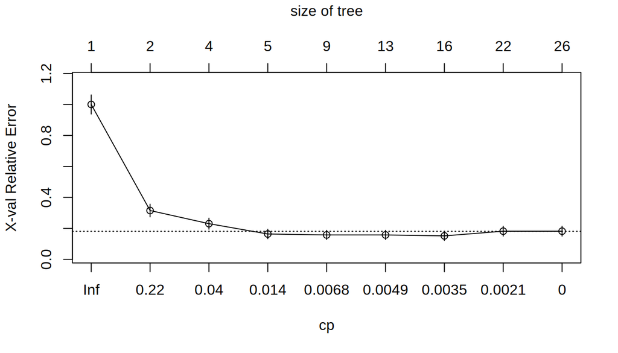

```r
plotcp(cv_tree)
```

Using 10-fold cross-validation on the training data only, the minimum cross-validated error occurs at 15 splits. Under the 1-SE rule, though, the simplest tree within one standard error of that minimum has **4 splits**. That tree is the baseline plus one extra split, `clump_thickness >= 7` inside the uniform-shape branch, which covers just 6 training cases (5 of them malignant). The default `minbucket = 7` is what kept the baseline from making this split. On the test set the CV tree makes exactly the same predictions as the baseline (99.1% accuracy), so I kept the simpler baseline. CV mainly confirms that a tree of about 3 to 4 splits is the right size.

Choosing `cp` by test-set score would make the test set part of training. The “best” score would be the maximum of many noisy estimates and therefore biased upward, and with 111 cases one patient is worth almost a full point of accuracy. There would then be no unbiased estimate left. Cross-validation picks the complexity without touching the test set.

# Bonus 3: Stability

```r
run_once <- function(seed) {
  set.seed(seed)
  idx <- unlist(lapply(split(seq_len(nrow(df)), df$class),
                       function(i) sample(i, round(0.8 * length(i)))))
  m <- rpart(class ~ ., data = df[idx, ], method = "class")
  ev <- evaluate(m, df[-idx, ])$metrics
  data.frame(root = as.character(m$frame$var[1]),
             splits = sum(m$frame$var != "<leaf>"),
             uses_bare_nuclei = "bare_nuclei" %in% m$frame$var,
             Accuracy = ev["Accuracy"], Sensitivity = ev["Sensitivity"],
             Specificity = ev["Specificity"], row.names = NULL)
}
stab <- do.call(rbind, lapply(1:50, run_once))

table(stab$root)
```

```
##
##              bare_nuclei uniformity_of_cell_shape  uniformity_of_cell_size
##                        4                       28                       18
```

```r
table(stab$splits)
```

```
##
##  2  3  4  5  6
##  7 33  8  1  1
```

```r
mean(stab$uses_bare_nuclei)
```

```
## [1] 0.74
```

```r
perf <- stab[, c("Accuracy", "Sensitivity", "Specificity")]
round(rbind(mean = colMeans(perf), sd = apply(perf, 2, sd),
            min = apply(perf, 2, min), max = apply(perf, 2, max)), 3)
```

```
##      Accuracy Sensitivity Specificity
## mean    0.941       0.928       0.949
## sd      0.027       0.052       0.031
## min     0.865       0.780       0.857
## max     0.991       1.000       1.000
```

Across 50 different seeds the root split was not fixed. It was uniformity_of_cell_shape (28), uniformity_of_cell_size (18), bare_nuclei (4). The swaps are mostly between cell shape and cell size uniformity, which carry nearly the same information, so which one wins depends on a few borderline patients. Trees usually had 3 splits, bare nuclei appeared in 74% of them, and the lower splits changed from run to run.

Performance also varied more than a single split suggests. Accuracy averaged 94.1% (range 86.5 to 99.1%) and sensitivity averaged 92.8% (range 78 to 100%). The main split’s 99% sits at the top of this range, and false positives do occur on other splits. Overall, on this dataset, trees perform consistently well but their structure is unstable. I would not over-interpret the specific variables in any single tree, I would report performance over several splits, and bagging or a random forest would be a natural next step to reduce this variance.

# AI Use Disclosure

- **Tool:** Claude (Anthropic).
- **How it was used:** to help write the R code and draft the written interpretation. I ran the code, checked the results against the output, and edited the text.
- **When:** during the analysis and write-up stage.